# AI Spam Detection Classifier

## Introduction

This notebook is part of the development of an AI model that will be able to predict whether an email is spam or not. This will be achieved using the Naïve Bayes machine learning algorithm and relevant datasets. The model will analyze the content of emails and make predictions based on this information to classify them as either spam or legitimate.

## Data sampling

Get 10 random samples from the dataset to get a first impression of the data. The data is split between 3 columns (features).

The data has the following features:

1. Label (ham or spam): This feature represents if the mail is spam or not-spam (ham). This feature will not be used in this notebook.
2. Label_num: This is a numerical representation of the label. In my project this will be used for training and testing.
3. Text: This contains the body (content) of the mails that the model will be trained and tested on.

```python
import pandas as pd

df = pd.read_csv('../Data/Emails.csv')
df.sample(10)
```

|  | label | label_num | text |
| --- | --- | --- | --- |
| 21019 | spam | 1 | subject re vallium vvlagra clalls hello would ... |
| 7920 | spam | 1 | subject wil this stock be a super nova mnei th... |
| 11304 | ham | 0 | subject tenaska iv receivables daren can you s... |
| 5202 | spam | 1 | subject via gra pro will get you hard consumpt... |
| 9583 | spam | 1 | subject one more time authentic replica rolex ... |
| 8791 | ham | 0 | subject fwd enjoy fall in an alamo midsize car... |
| 18419 | spam | 1 | subject fast delivery prescripiton drvgs brads... |
| 19931 | ham | 0 | subject re recommendation of an outstanding ba... |
| 28433 | spam | 1 | subject allas plnnacle system apple corel nero... |
| 9112 | ham | 0 | subject re matt hommel it is a touching messag... |

### Check what the distribution of data is between the mails in the training set (spam or not)

```python
if "label" in df:
    df = df.drop("label", axis=1)

df["label_num"].dropna()
spam_count = 0
nonspam_count = 0

for value in df["label_num"]:
    if value == 1:
        spam_count += 1
    elif value == 0:
        nonspam_count += 1


print(f"Amount of mails that are spam: {spam_count}")
print(f"Amount of mails that are not spam: {nonspam_count}")
```

```
Amount of mails that are spam: 17157
Amount of mails that are not spam: 16545
```

# Preprocessing

## Target Variable

As mentioned earlier the model will only be using the label_num from the dataset representing a numerical value for each mail (0 or 1). Because this will be used in the training set, it be the target variable too. This is because the model should classify the mail as either spam or not spam, so the most logical choise is to output it that way. The output will be 0 (non-spam) or 1 (spam.)

## Data Cleaning

### Remove stopwords from the dataset.

In this step, I eliminate common stopwords such as "I," "me," "in," "the," and "is." These words contribute little value to the dataset as they frequently occur in text and add noise. Removing them helps clean the data, making predictions more precise by removing noise. This process enhances the efficiency and accuracy of machine learning models, this is especially useful for tasks like text classification or sentiment analysis, which I will be using later.

```python
from nltk.corpus import stopwords
from nltk.tokenize import word_tokenize

stop_words = set(stopwords.words('english'))

def remove_stopwords(text):
    text_tokenized = word_tokenize(text)
    filtered_sentence = [w for w in text_tokenized if not w.lower() in stop_words]
    return ' '.join(filtered_sentence)

df['filtered_text'] = df['text'].apply(remove_stopwords)

print(df['filtered_text'].head(10))
print(df['text'].head(10))
```

```
0    subject fw weather sites list weather sites pr...
1    subject cant believe changma wow wow wow unbel...
2    subject 4 color printing special request addit...
3    subject nobody beat us poloponybreakaway ionme...
4    subject energy extravaganza 2 weeks away energ...
5    subject clear benefits creative design lt real...
6    subject fw pma bill following message heather ...
7    subject li sun vince glad meeting went well li...
8    subject bill koures vince alex phone interview...
9    subject seasonal factors curve fitting written...
Name: filtered_text, dtype: object
0    subject fw weather sites this is the list of w...
1    subject i cant believe the changma wow wow wow...
2    subject 4 color printing special request addit...
3    subject nobody can beat us poloponybreakaway i...
4    subject energy extravaganza 2 weeks away energ...
5    subject clear benefits of creative design lt i...
6    subject fw pma s bill the following is a messa...
7    subject li sun vince i am so glad that your me...
8    subject bill koures vince alex and i did a pho...
9    subject seasonal factors and curve fitting i h...
Name: text, dtype: object
```

# Exploratory Data Analysis

## Creating word clouds to get an insight of the word usage

Here i look at the most common words that are used in both spam and non spam mails. This can give good insights for classifying the mail. When we know what words are more likely to occur in spam mails, this will have more value, and we can assume that the mail will be spam, based on the word usage.

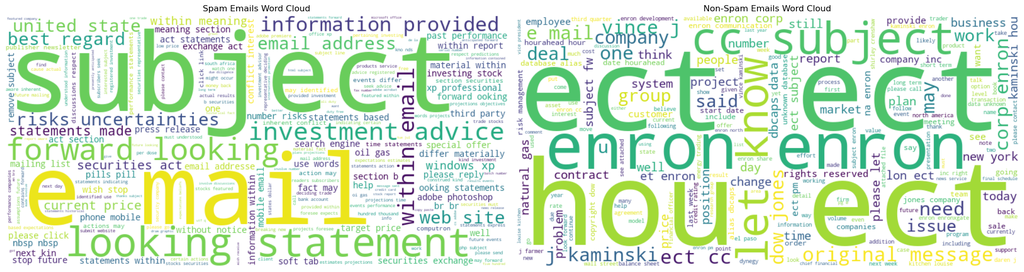

```python
from wordcloud import WordCloud
import matplotlib.pyplot as plt

spam_emails = df[df['label_num'] == 1]['filtered_text']
non_spam_emails = df[df['label_num'] == 0]['filtered_text']

spam_text = ' '.join(spam_emails)
non_spam_text = ' '.join(non_spam_emails)

spam_wordcloud = WordCloud(width=800, height=400, background_color='white').generate(spam_text)
non_spam_wordcloud = WordCloud(width=800, height=400, background_color='white').generate(non_spam_text)

plt.figure(figsize=(20, 6))

plt.subplot(1, 2, 1)
plt.imshow(spam_wordcloud, interpolation='bilinear')
plt.axis('off')
plt.title('Spam Emails Word Cloud')

plt.subplot(1, 2, 2)
plt.imshow(non_spam_wordcloud, interpolation='bilinear')
plt.axis('off')
plt.title('Non-Spam Emails Word Cloud')

plt.tight_layout()
plt.show()
```

### Look what the most common words are in spam and non-spam mails

This is a similar step to previous one, only here the words are counted and visualized in a bar chart. This can also give more insights as we know how often a word occurs, rather than what words.

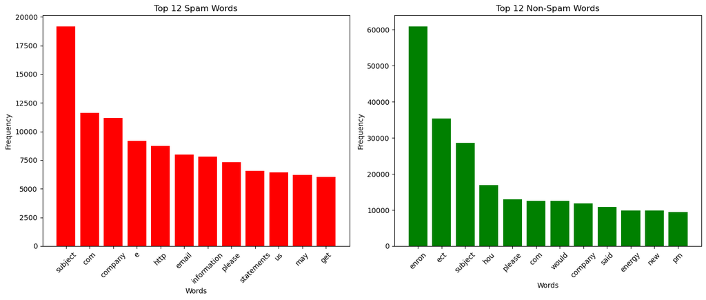

```python
from collections import Counter
import re

spam_emails = df[df['label_num'] == 1]['filtered_text']
non_spam_emails = df[df['label_num'] == 0]['filtered_text']

def preprocess_text(text):
    text = re.sub(r'[^a-zA-Z\s]', '', text.lower())
    words = text.split()
    return words

spam_words = [word for email in spam_emails for word in preprocess_text(email)]
spam_word_counts = Counter(spam_words)

non_spam_words = [word for email in non_spam_emails for word in preprocess_text(email)]
non_spam_word_counts = Counter(non_spam_words)

N = 12
top_spam_words = spam_word_counts.most_common(N)
top_non_spam_words = non_spam_word_counts.most_common(N)

spam_words, spam_counts = zip(*top_spam_words)
non_spam_words, non_spam_counts = zip(*top_non_spam_words)

plt.figure(figsize=(14, 6))

plt.subplot(1, 2, 1)
plt.bar(spam_words, spam_counts, color='red')
plt.title('Top {} Spam Words'.format(N))
plt.xlabel('Words')
plt.ylabel('Frequency')
plt.xticks(rotation=45)

plt.subplot(1, 2, 2)
plt.bar(non_spam_words, non_spam_counts, color='green')
plt.title('Top {} Non-Spam Words'.format(N))
plt.xlabel('Words')
plt.ylabel('Frequency')
plt.xticks(rotation=45)

plt.tight_layout()
plt.show()
```

## Correlation matrix

Here i made a correlation matrix between my featues. The features in my case are the words from the text. This matrix shows how important the words are to predict if the mail is spam. Correlations with a higher number (0-1) will have more impact in predicting the mail as spam, because those words will be associated with spam.

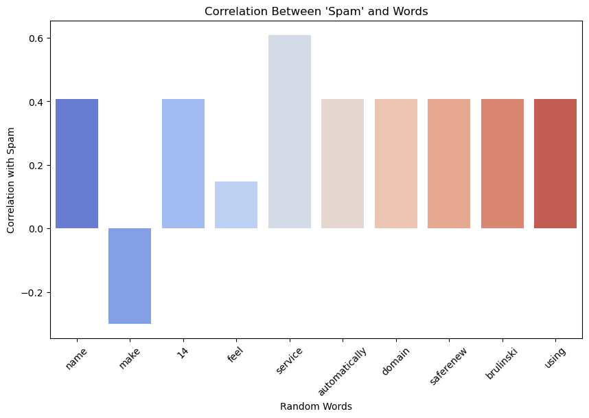

```python
import seaborn as sns
import matplotlib.pyplot as plt
import pandas as pd
from sklearn.feature_extraction.text import TfidfVectorizer
import numpy as np


vectorizer = TfidfVectorizer(max_features=100)
X_text = vectorizer.fit_transform(df['filtered_text'].sample(10))

X_text_df = pd.DataFrame(X_text.toarray(), columns=vectorizer.get_feature_names_out())

num_random_words = 10
random_words = np.random.choice(X_text_df.columns, num_random_words, replace=False)

X_text_random_df = X_text_df[random_words]

df_combined = pd.concat([df['label_num'], X_text_random_df], axis=1)

correlations = df_combined.corr()

correlations = correlations.iloc[0, 1:]

correlations_df = correlations.reset_index()
correlations_df.columns = ["word", "correlation"]

plt.figure(figsize=(10, 6))
sns.barplot(
    data=correlations_df,
    x="word",
    y="correlation",
    palette="coolwarm",
    hue="word",
    dodge=False,
    legend=False
)
plt.title("Correlation Between 'Spam' and Words")
plt.xlabel("Random Words")
plt.ylabel("Correlation with Spam")
plt.xticks(rotation=45)
plt.show()
```

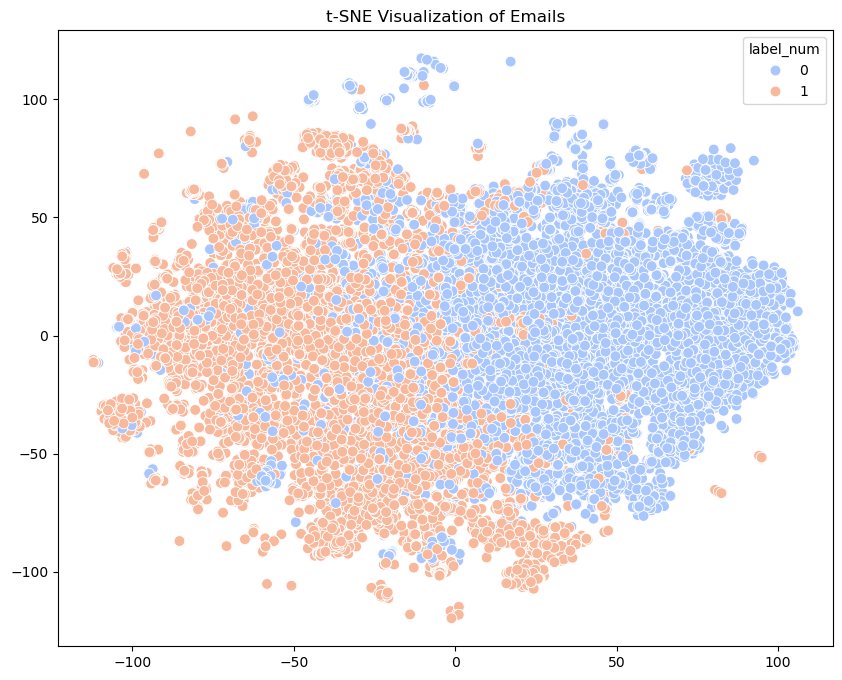

```python
from sklearn.manifold import TSNE

tsne = TSNE(n_components=2, random_state=42)
X = vectorizer.fit_transform(df['filtered_text'])
tsne_results = tsne.fit_transform(X.toarray())

plt.figure(figsize=(10, 8))
sns.scatterplot(x=tsne_results[:, 0], y=tsne_results[:, 1], hue=df['label_num'], palette='coolwarm', s=60)
plt.title('t-SNE Visualization of Emails')
plt.show()
```

# Modelling

Here I import the MultinomialNB Naive Bayes algorithm. This algorthim is a text classification algorithm that will be used to classify the prediction of the mail. I use TfidfVectorizer to convert the raw text from the data into a TF-IDF Matrix. The matrix is used to create numerical representations of the words based on their importance.

```python
from sklearn.feature_extraction.text import TfidfVectorizer
from sklearn.naive_bayes import MultinomialNB
from sklearn.model_selection import train_test_split
from sklearn.metrics import accuracy_score

vectorizer = TfidfVectorizer()

X = df["filtered_text"]
Y = df["label_num"]

X = vectorizer.fit_transform(X)

X_train, X_test, Y_train, Y_test = train_test_split(X, Y, test_size=0.2)

ModelNB = MultinomialNB()

ModelNB.fit(X_train, Y_train)

prediction = ModelNB.predict(X_test)
accuracyNB = accuracy_score(Y_test, prediction)
```

##### I Initially used the Naive Bayes algorithm to classify the mails as spam. Here i import the Support Vector Machine (SVM) algorithm to compare the results between the 2 algorithms

```python
from sklearn.feature_extraction.text import TfidfVectorizer
from sklearn.svm import SVC
from sklearn.model_selection import train_test_split
from sklearn.metrics import accuracy_score

vectorizer = TfidfVectorizer()

X = df["filtered_text"]
Y = df["label_num"]

X = vectorizer.fit_transform(X)

X_train, X_test, Y_train, Y_test = train_test_split(X, Y, test_size=0.2)

ModelSVM = SVC(kernel='linear')

ModelSVM.fit(X_train, Y_train)

prediction = ModelSVM.predict(X_test)
accuracySVM = accuracy_score(Y_test, prediction)
```

# Evaluation

After the training phase, we need to evaluate how well the model performs. One common metric for classification algorithms, like those used in this notebook, is the accuracy score. Accuracy measures the proportion of correctly predicted instances out of the total instances. It provides insight into the overall performance of the model.

The accuracy score ranges from 0 to 1, where higher values indicate better performance. However, while accuracy is useful, it may not always be the best metric, especially for imbalanced datasets, where other metrics like precision, recall, or F1-score might be more uesful.

```python
print(f"Naive Bayes Accuracy: {accuracyNB}")
print(f"SVM Accuracy: {accuracySVM}")
```

```
Naive Bayes Accuracy: 0.9845720219551996
SVM Accuracy: 0.9931760866340306
```

### K-Fold Cross Validation

In this section, I apply K-Fold Cross Validation to evaluate the model's performance. Cross-validation splits the dataset into multiple folds or subsets, ensuring the model is trained and tested on different parts of the data. This approach helps assess whether the model's high accuracy (0.98) is consistent or just a coincidence.

By using cross-validation, I can ensure that the model works well with new unseen data, reducing the risk of overfitting and providing a more reliable measure of its accuracy.

Cross validation on the Naive Bayes Model

```python
from sklearn.model_selection import cross_val_score
import numpy as np

cv_scores = cross_val_score(ModelNB, X, Y, cv=5, scoring='accuracy')

print(f"Cross-Validation Scores: {cv_scores}")
print(f"Mean Accuracy: {np.mean(cv_scores)}")
```

```
Cross-Validation Scores: [0.98531375 0.98620383 0.98620178 0.9851632  0.98501484]
Mean Accuracy: 0.9855794801905343
```

Cross validation on the Support Vector Machine Model

```python
from sklearn.model_selection import cross_val_score
import numpy as np

cv_scores = cross_val_score(ModelSVM, X, Y, cv=5, scoring='accuracy')

print(f"Cross-Validation Scores: {cv_scores}")
print(f"Mean Accuracy: {np.mean(cv_scores)}")
```

```
Cross-Validation Scores: [0.99006082 0.99198932 0.99272997 0.99154303 0.99183976]
Mean Accuracy: 0.9916325801145126
```

## Confusion Matrix

To see how often the model is correct or incorrect (False Positives/ False Negatives). I have made a confiusion matrix. This shows the evaluation of the model by looking at how ofter the model predict a mail as spam when its not spam and how often the model predicts a mail as non spam when its actually spam. Both metrics are important to track, because when the model classifier a mail as spam when its not, important messages could get lost. Also the other way arround, when the model doesnt classify a mails as spam and it comes to an user's mailbox there is a risk of the user clicking on a malicious/unwanted link.

### Confiusion matrix for the Naive Bayes Model

```
Accuracy: 0.9902091677792613
```

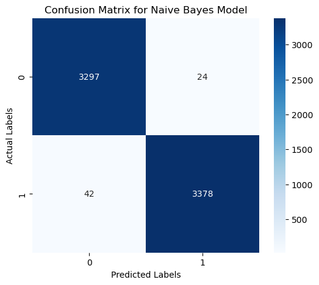

```
Classification Report:
              precision    recall  f1-score   support

           0       0.99      0.99      0.99      3321
           1       0.99      0.99      0.99      3420

    accuracy                           0.99      6741
   macro avg       0.99      0.99      0.99      6741
weighted avg       0.99      0.99      0.99      6741
```

```python
from sklearn.metrics import confusion_matrix, accuracy_score, classification_report
import seaborn as sns
import matplotlib.pyplot as plt

prediction = ModelNB.predict(X_test)

accuracyNB = accuracy_score(Y_test, prediction)
print(f"Accuracy: {accuracyNB}")

cm = confusion_matrix(Y_test, prediction)

plt.figure(figsize=(6, 5))
sns.heatmap(cm, annot=True, fmt='d', cmap='Blues', xticklabels=df['label_num'].unique(), yticklabels=df['label_num'].unique())
plt.xlabel('Predicted Labels')
plt.ylabel('Actual Labels')
plt.title('Confusion Matrix for Naive Bayes Model')
plt.show()

print("Classification Report:")
print(classification_report(Y_test, prediction))
```

### Confusion matrix for the Support Vector Machine model

```
Accuracy: 0.9931760866340306
```

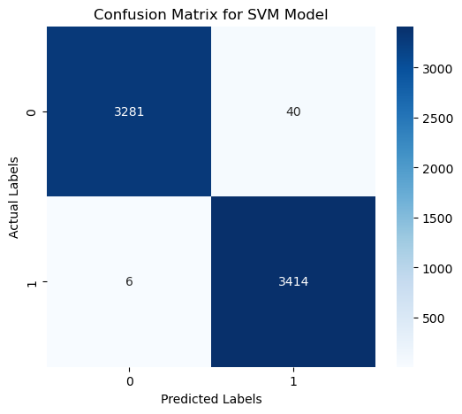

```
Classification Report:
              precision    recall  f1-score   support

           0       1.00      0.99      0.99      3321
           1       0.99      1.00      0.99      3420

    accuracy                           0.99      6741
   macro avg       0.99      0.99      0.99      6741
weighted avg       0.99      0.99      0.99      6741
```

```python
from sklearn.metrics import confusion_matrix, accuracy_score, classification_report
import seaborn as sns
import matplotlib.pyplot as plt

prediction = ModelSVM.predict(X_test)

accuracySVM = accuracy_score(Y_test, prediction)
print(f"Accuracy: {accuracySVM}")

cm = confusion_matrix(Y_test, prediction)

plt.figure(figsize=(6, 5))
sns.heatmap(cm, annot=True, fmt='d', cmap='Blues', xticklabels=df['label_num'].unique(), yticklabels=df['label_num'].unique())
plt.xlabel('Predicted Labels')
plt.ylabel('Actual Labels')
plt.title('Confusion Matrix for SVM Model')
plt.show()

print("Classification Report:")
print(classification_report(Y_test, prediction))
```

## Exporting the model

To make the model available for use on a website/app, it is exported as a .pkl file. This file contains the trained model, which can be directly loaded and used on a website/app to make classifications.

```python
import pickle
import os

folder_name = "../Models"
os.makedirs(folder_name, exist_ok=True)

with open(os.path.join(folder_name, "modelNB.pkl"), "wb") as model_file:
    pickle.dump(ModelNB, model_file)

with open(os.path.join(folder_name, "vectorizerNB.pkl"), "wb") as vectorizer_file:
    pickle.dump(vectorizer, vectorizer_file)
```

```python
with open(os.path.join(folder_name, "modelSVM.pkl"), "wb") as model_file:
    pickle.dump(ModelSVM, model_file)

with open(os.path.join(folder_name, "vectorizerSVM.pkl"), "wb") as vectorizer_file:
    pickle.dump(vectorizer, vectorizer_file)
```